# **Генерация датасета с заданными в условии параметрами**

```python
import numpy as np
import pandas as pd
import statsmodels.api as sm
import matplotlib.pyplot as plt
import seaborn as sns
from scipy import stats

N = 1000
mu = [0, 0]
cov = [[1, -0.7],
       [-0.7, 1]]

np.random.seed(42)
X = np.random.multivariate_normal(mu, cov, N)
x1, x2 = X[:, 0], X[:, 1]

# Генерация y: y = beta0 + beta1*x1 + beta2*x2 + eps
beta0, beta1, beta2 = 5, 2.5, -1.5
eps = np.random.normal(0, 1, N)
y = beta0 + beta1 * x1 + beta2 * x2 + eps

df = pd.DataFrame({'y': y, 'x1': x1, 'x2': x2})
```

# **Оценка модели методом МНК и проверка остатков на нормальность**

МНК очень точно восстановил заданные параметры. Коэффициенты $\hat{\beta}_1 \approx 2.5071$ и $\hat{\beta}_2 \approx -1.4628$ практически идентичны тем, что мы закладывали при генерации ($2.5$ и $-1.5$). Все p-values равны $0.000$. Это значит, что переменные $x_1$ и $x_2$ статистически значимо влияют на $y$. Качество ($R^2 = 0.929$) говорит о том, что модель объясняет $93\%$ изменчивости данных.

Проврека на нормальность остатков: Так как $p > 0.05$, мы принимаем гипотезу о том, что остатки распределены нормально.

```python
X_model = sm.add_constant(df[['x1', 'x2']])
model = sm.OLS(df['y'], X_model).fit()

print(model.summary())

# Тест на нормальность остатков
jb_test = stats.jarque_bera(model.resid)
print(f"\nТест Харке-Бера: Статистика={jb_test[0]:.4f}, p-value={jb_test[1]:.4f}")
```

```
                            OLS Regression Results
==============================================================================
Dep. Variable:                      y   R-squared:                       0.929
Model:                            OLS   Adj. R-squared:                  0.928
Method:                 Least Squares   F-statistic:                     6474.
Date:                Thu, 26 Feb 2026   Prob (F-statistic):               0.00
Time:                        15:15:31   Log-Likelihood:                -1401.2
No. Observations:                1000   AIC:                             2808.
Df Residuals:                     997   BIC:                             2823.
Df Model:                           2
Covariance Type:            nonrobust
==============================================================================
                 coef    std err          t      P>|t|      [0.025      0.975]
------------------------------------------------------------------------------
const          5.0039      0.031    160.476      0.000       4.943       5.065
x1             2.5071      0.043     57.826      0.000       2.422       2.592
x2            -1.4628      0.043    -33.804      0.000      -1.548      -1.378
==============================================================================
Omnibus:                        1.796   Durbin-Watson:                   2.024
Prob(Omnibus):                  0.407   Jarque-Bera (JB):                1.687
Skew:                           0.059   Prob(JB):                        0.430
Kurtosis:                       3.163   Cond. No.                         2.26
==============================================================================

Notes:
[1] Standard Errors assume that the covariance matrix of the errors is correctly specified.

Тест Харке-Бера: Статистика=1.6874, p-value=0.4301
```

# **Отрисовка графиков**

По графикам y vs x1 и y vs x2 мы видим, что переменные x1 и x2 имеют, соотвественно, прямое и обратное влияние на y. Это соотвествует значениям коэффициентов ${\beta}_1 = 2.5$ (положительный) и ${\beta}_2 = -1.5$ (отрицательный)

График $y$ vs $\hat{y}$ - это главный индикатор качества модели. Чем ближе точки к диагонали, тем выше точность предсказания. Тот факт, что разброс минимален, соответствует высокому показателю $R^2 = 0.929$. Модель объясняет почти $93\%$ изменчивости целевой переменной, а значит, предсказанные значения $\hat{y}$ очень близки к реальным $y$.

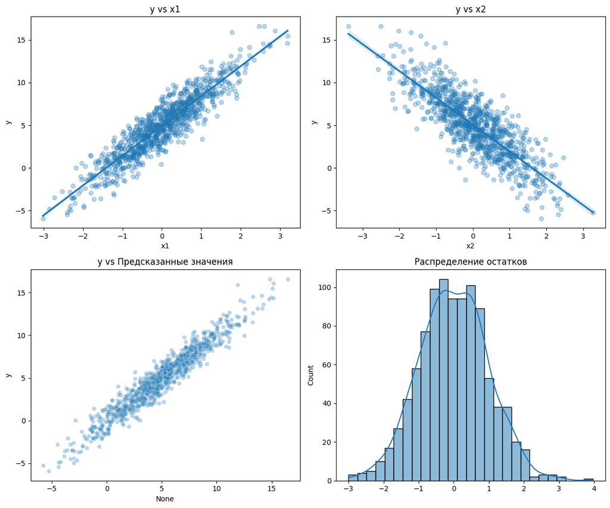

```python
fig, axes = plt.subplots(2, 2, figsize=(12, 10))

sns.regplot(x='x1', y='y', data=df, ax=axes[0, 0], scatter_kws={'alpha':0.3})
axes[0, 0].set_title('y vs x1')

sns.regplot(x='x2', y='y', data=df, ax=axes[0, 1], scatter_kws={'alpha':0.3})
axes[0, 1].set_title('y vs x2')

sns.scatterplot(x=model.fittedvalues, y=df['y'], ax=axes[1, 0], alpha=0.3)
axes[1, 0].set_title('y vs Предсказанные значения')

sns.histplot(model.resid, kde=True, ax=axes[1, 1])
axes[1, 1].set_title('Распределение остатков')

plt.tight_layout()
plt.show()
```

# **Графики зависимости оценок коэффициентов $\hat{\beta}_1$ и $\hat{\beta}_2$ в зависимости от размера выборки $N$**

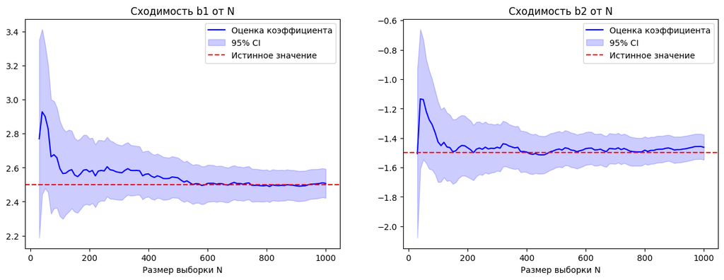

```python
results = []
for n in range(30, 1001, 10):
    X_n = X_model.iloc[:n]
    y_n = y[:n]
    res_n = sm.OLS(y_n, X_n).fit()

    results.append({
        'N': n,
        'b1': res_n.params['x1'],
        'b1_se': res_n.bse['x1'],
        'b2': res_n.params['x2'],
        'b2_se': res_n.bse['x2']
    })

res_df = pd.DataFrame(results)
res_df['b1_up'] = res_df['b1'] + 1.96 * res_df['b1_se']
res_df['b1_low'] = res_df['b1'] - 1.96 * res_df['b1_se']
res_df['b2_up'] = res_df['b2'] + 1.96 * res_df['b2_se']
res_df['b2_low'] = res_df['b2'] - 1.96 * res_df['b2_se']

# Графики
fig, ax = plt.subplots(1, 2, figsize=(15, 5))

for i, b in enumerate(['b1', 'b2']):
    true_val = beta1 if b == 'b1' else beta2
    ax[i].plot(res_df['N'], res_df[b], label='Оценка коэффициента', color='blue')
    ax[i].fill_between(res_df['N'], res_df[f'{b}_low'], res_df[f'{b}_up'], color='blue', alpha=0.2, label='95% CI')
    ax[i].axhline(true_val, color='red', linestyle='--', label='Истинное значение')
    ax[i].set_title(f'Сходимость {b} от N')
    ax[i].set_xlabel('Размер выборки N')
    ax[i].legend()

plt.show()
```